# Statistical Inference Course Project

Emanuel Calvo

October 25, 2015

## Part “A”

### Overview

In this project you will investigate the exponential distribution in R and compare it with the Central Limit Theorem. The exponential distribution can be simulated in R with *rexp(n, lambda)* where lambda is the rate parameter. The mean of exponential distribution is 1/lambda and the standard deviation is also 1/lambda. Set lambda = 0.2 for all of the simulations. You will investigate the distribution of averages of 40 exponentials. Note that you will need to do a thousand simulations.

Illustrate via simulation and associated explanatory text the properties of the distribution of the mean of 40 exponentials. You should 1. Show the sample mean and compare it to the theoretical mean of the distribution. 2. Show how variable the sample is (via variance) and compare it to the theoretical variance of the distribution. 3. Show that the distribution is approximately normal.

In point 3, focus on the difference between the distribution of a large collection of random exponentials and the distribution of a large collection of averages of 40 exponentials.

### Simulations

The code bellow, creates a vector of means of a exponentionaly distributed random variables, generated by the function `rexp`. In this particular case, in order to help the repeteability of the current code, you’ll see the `set.seed` function which is in charge of set a fixed seed.

```r
set.seed(600)

n = 40
lambda = 0.2

mns = NULL
simulations <- 1000

meanRExp <- function(x){
  mean(rexp(n, lambda))
}

mns <- sapply(seq(1,simulations), meanRExp)
cumVar <- sapply(seq(1,simulations), function(x){var(rexp(n, lambda))})
```

Means summary:

```r
summary(mns)
```

```
##    Min. 1st Qu.  Median    Mean 3rd Qu.    Max.
##   2.861   4.489   4.965   5.020   5.525   8.330
```

#### Sample Mean and Theorical Mean

For the current scenario, we must consider the following as the theorical mean of a exponential distribution:

$\frac{1}{\lambda} = \frac{1}{0.2} = 5$

The sample mean can be calculated using:

```r
distMean <- mean(mns)
```

The center of the sample distribution for the current study is 5.0200217. This is very closer to the theorical mean defined above.

#### Theorical and Sample Variances

The theorical standard deviation of a exponential distibution will look like the following expression:

$\frac{\frac{1}{\lambda}}{\sqrt{n}} = \frac{\frac{1}{0.2}}{\sqrt{40}} \simeq .790$

The sample’s standard deviation

```r
sampleSd <- sd(mns)
sampleSd
```

```
## [1] 0.78609
```

The theorical expected variance is represented by:

$( \frac{\frac{1}{\lambda}}{\sqrt{n}} ) ^ 2 = ( \frac{\frac{1}{0.2}}{\sqrt{40}} ) ^ 2 = .625$

Sample variance is:

```r
tVar = ((1/lambda) / sqrt(n) ) ^ 2
var(mns)
```

```
## [1] 0.6179375
```

> As we observed above, we were able to calculate approximately the variance.

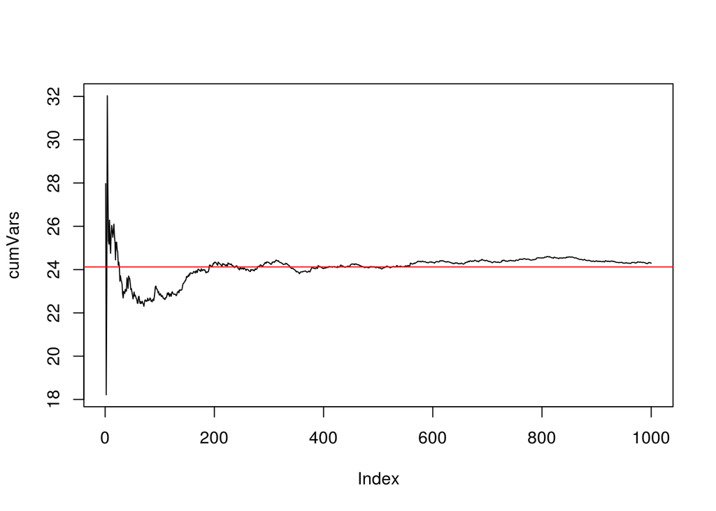

```r
cumVars <- cumsum(cumVar)/(1:simulations)
meanCumVars <- mean(cumVars)
plot( cumVars, type = "l" )
abline(h = meanCumVars, col = "red" )
```

### Show that the distribution is approximately normal

The graph bellow shows a bell courve as a result of the normal distribution function using the mean of all the sample means and the standard deviation by result of the following formula:

$\sqrt{var(X)}$

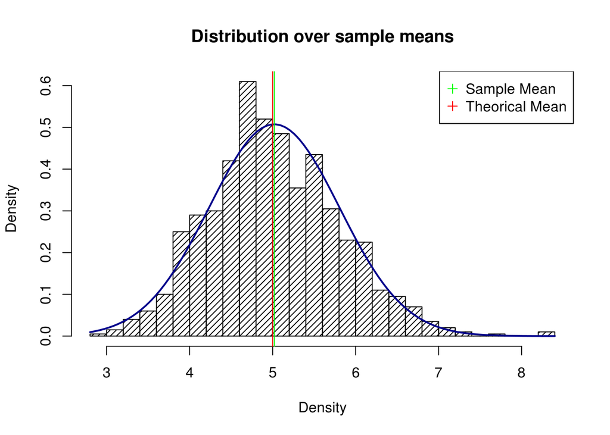

```r
m<-mean(mns)
std<-sqrt(var(mns))

hist(mns, density=20, breaks=20, prob=TRUE,
         xlab="Density",
         main="Distribution over sample means")
curve(dnorm(x, mean=m, sd=std),
          col="darkblue", lwd=2, add=TRUE, yaxt="n")
abline(v = 5, col="red")
abline(v = distMean, col = "green")

legend("topright", pch = c(3,3) ,
        col = c("green", "red"),
        legend = c("Sample Mean", "Theorical Mean"))
```